# idx-finalproject

#### Project Overview:

This project involves a comprehensive analysis of loan data, specifically focusing on data from ID/X Partners. The dataset contains various features related to loans, including loan amounts, interest rates, borrower information, and loan status. The goal is to gain insights into the factors influencing loan performance, visualize trends over time, and make informed suggestions for optimizing business strategies.

### Import necessary libraries

```python
# Import libraries
import numpy as np
import pandas as pd
import matplotlib.pyplot as plt
import seaborn as sns
import plotly.express as px
```

### Data preprocessing

```python
# Load the dataframe
loan_data = pd.read_csv('/kaggle/input/loan-data/loan_data_2007_2014.csv', low_memory=False)
```

```python
# Print dataframe head row
loan_data.head()
```

|  | Unnamed: 0 | id | member_id | loan_amnt | funded_amnt | funded_amnt_inv | term | int_rate | installment | grade | sub_grade | emp_title | emp_length | home_ownership | annual_inc | verification_status | issue_d | loan_status | pymnt_plan | url | desc | purpose | title | zip_code | addr_state | dti | delinq_2yrs | earliest_cr_line | inq_last_6mths | … |
| --- | --- | --- | --- | --- | --- | --- | --- | --- | --- | --- | --- | --- | --- | --- | --- | --- | --- | --- | --- | --- | --- | --- | --- | --- | --- | --- | --- | --- | --- | --- |
| 0 | 0 | 1077501 | 1296599 | 5000 | 5000 | 4975.0 | 36 months | 10.65 | 162.87 | B | B2 | NaN | 10+ years | RENT | 24000.0 | Verified | Dec-11 | Fully Paid | n | https://www.lendingclub.com/browse/loanDetail.... | Borrower added on 12/22/11 > I need to upgra... | credit_card | Computer | 860xx | AZ | 27.65 | 0.0 | Jan-85 | 1.0 | … |
| 1 | 1 | 1077430 | 1314167 | 2500 | 2500 | 2500.0 | 60 months | 15.27 | 59.83 | C | C4 | Ryder | < 1 year | RENT | 30000.0 | Source Verified | Dec-11 | Charged Off | n | https://www.lendingclub.com/browse/loanDetail.... | Borrower added on 12/22/11 > I plan to use t... | car | bike | 309xx | GA | 1.00 | 0.0 | Apr-99 | 5.0 | … |
| 2 | 2 | 1077175 | 1313524 | 2400 | 2400 | 2400.0 | 36 months | 15.96 | 84.33 | C | C5 | NaN | 10+ years | RENT | 12252.0 | Not Verified | Dec-11 | Fully Paid | n | https://www.lendingclub.com/browse/loanDetail.... | NaN | small_business | real estate business | 606xx | IL | 8.72 | 0.0 | Nov-01 | 2.0 | … |
| 3 | 3 | 1076863 | 1277178 | 10000 | 10000 | 10000.0 | 36 months | 13.49 | 339.31 | C | C1 | AIR RESOURCES BOARD | 10+ years | RENT | 49200.0 | Source Verified | Dec-11 | Fully Paid | n | https://www.lendingclub.com/browse/loanDetail.... | Borrower added on 12/21/11 > to pay for prop... | other | personel | 917xx | CA | 20.00 | 0.0 | Feb-96 | 1.0 | … |
| 4 | 4 | 1075358 | 1311748 | 3000 | 3000 | 3000.0 | 60 months | 12.69 | 67.79 | B | B5 | University Medical Group | 1 year | RENT | 80000.0 | Source Verified | Dec-11 | Current | n | https://www.lendingclub.com/browse/loanDetail.... | Borrower added on 12/21/11 > I plan on combi... | other | Personal | 972xx | OR | 17.94 | 0.0 | Jan-96 | 0.0 | … |

```python
# Display dataframe info
loan_data.info()
```

```
<class 'pandas.core.frame.DataFrame'>
RangeIndex: 466285 entries, 0 to 466284
Data columns (total 75 columns):
 #   Column                       Non-Null Count   Dtype
---  ------                       --------------   -----
 0   Unnamed: 0                   466285 non-null  int64
 1   id                           466285 non-null  int64
 2   member_id                    466285 non-null  int64
 3   loan_amnt                    466285 non-null  int64
 4   funded_amnt                  466285 non-null  int64
 5   funded_amnt_inv              466285 non-null  float64
 6   term                         466285 non-null  object
 7   int_rate                     466285 non-null  float64
 8   installment                  466285 non-null  float64
 9   grade                        466285 non-null  object
```

[output cut: 67 more lines]

```python
# Drop irrelevant columns
loan_data.drop(['Unnamed: 0', 'url'], axis=1, inplace=True)
```

```python
# Convert date-value columns to datetime with explicit date format
loan_data['issue_d'] = pd.to_datetime(loan_data['issue_d'], format='%b-%y')
loan_data['next_pymnt_d'] = pd.to_datetime(loan_data['next_pymnt_d'], format='%b-%y')
loan_data['last_pymnt_d'] = pd.to_datetime(loan_data['last_pymnt_d'], format='%b-%y')
loan_data['last_credit_pull_d'] = pd.to_datetime(loan_data['last_credit_pull_d'], format='%b-%y')

# Print datetime columns
print(loan_data[['issue_d', 'next_pymnt_d', 'last_pymnt_d', 'last_credit_pull_d']])
```

```
          issue_d next_pymnt_d last_pymnt_d last_credit_pull_d
0      2011-12-01          NaT   2015-01-01         2016-01-01
1      2011-12-01          NaT   2013-04-01         2013-09-01
2      2011-12-01          NaT   2014-06-01         2016-01-01
3      2011-12-01          NaT   2015-01-01         2015-01-01
4      2011-12-01   2016-02-01   2016-01-01         2016-01-01
...           ...          ...          ...                ...
466280 2014-01-01   2016-02-01   2016-01-01         2016-01-01
466281 2014-01-01          NaT   2014-12-01         2016-01-01
466282 2014-01-01   2016-02-01   2016-01-01         2015-12-01
466283 2014-01-01          NaT   2014-12-01         2015-04-01
466284 2014-01-01   2016-02-01   2016-01-01         2016-01-01

[466285 rows x 4 columns]
```

```python
# Handling missing data

# Identify numerical and categorical columns
numerical_columns = loan_data.select_dtypes(include=['float64', 'int64']).columns
categorical_columns = loan_data.select_dtypes(include=['object']).columns

# Fill missing values in numerical columns with the mean
loan_data[numerical_columns] = loan_data[numerical_columns].fillna(loan_data[numerical_columns].mean())

# Fill missing values in categorical columns with "Not specified"
loan_data[categorical_columns] = loan_data[categorical_columns].fillna("Not specified")
```

### Initial findings

```python
# Initial findings

# Select columns to find initial insights
use_cols = ['loan_amnt', 'funded_amnt', 'int_rate', 'grade',
            'annual_inc', 'dti', 'open_acc', 'pub_rec',
            'revol_bal', 'total_acc', 'loan_status', 'int_rate',
            'issue_d', 'next_pymnt_d', 'last_pymnt_d']

df = loan_data[use_cols]
```

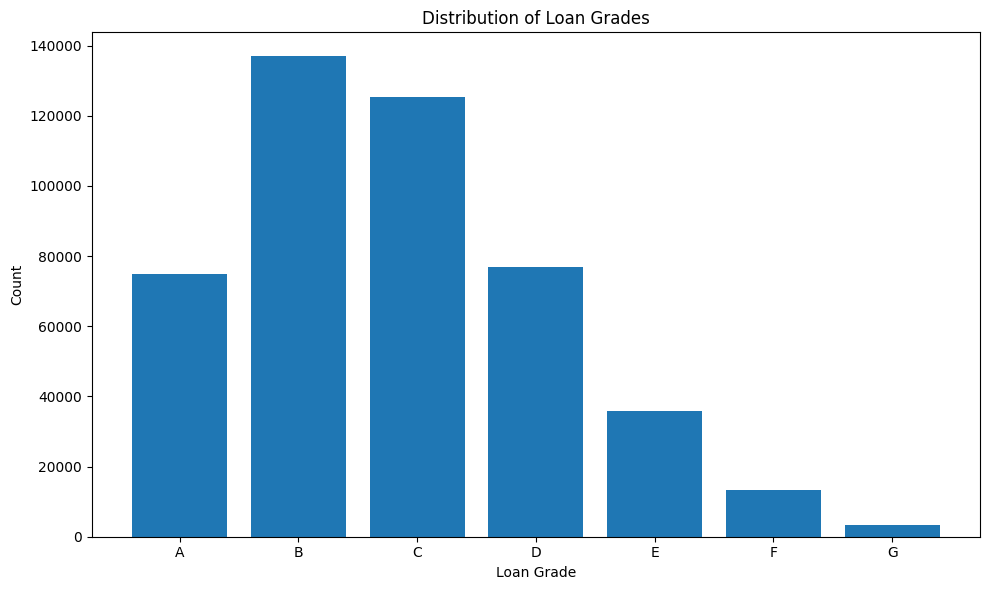

```python
# Visualize loan grade distribution
plt.figure(figsize=(10, 6))
grades_order = sorted(df['grade'].unique())
grade_counts = df['grade'].value_counts()[grades_order]
plt.bar(grades_order, grade_counts)
plt.title('Distribution of Loan Grades')
plt.xlabel('Loan Grade')
plt.ylabel('Count')
plt.tight_layout()
plt.savefig('/kaggle/working/loan_grades.png')
plt.show()
```

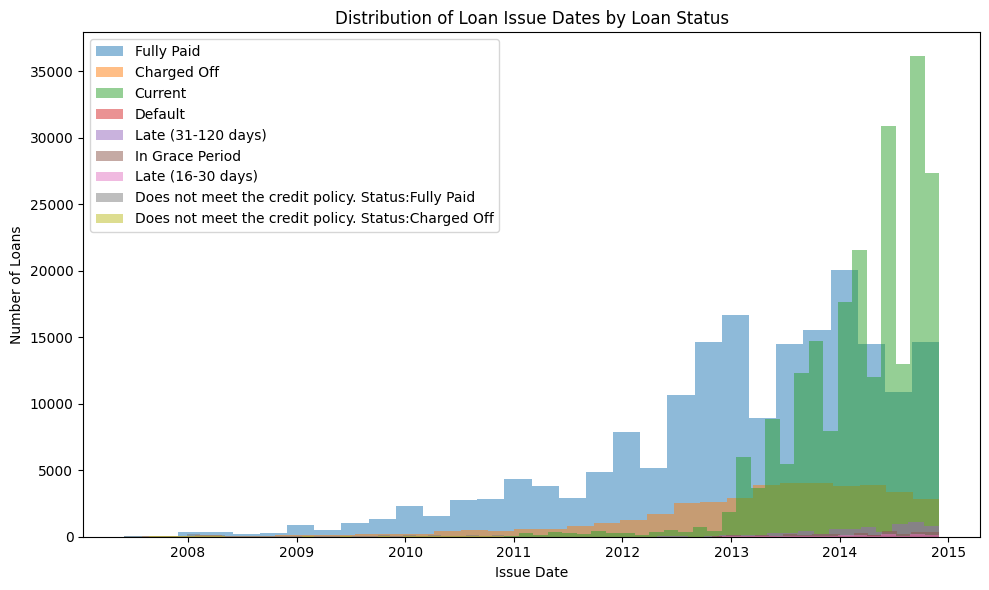

```python
# Visualize the distribution of issue date based on loan status
plt.figure(figsize=(10, 6))
loan_status_values = df['loan_status'].unique()
for status in loan_status_values:
    plt.hist(df[df['loan_status'] == status]['issue_d'], bins=30, alpha=0.5, label=status)
plt.title('Distribution of Loan Issue Dates by Loan Status')
plt.xlabel('Issue Date')
plt.ylabel('Number of Loans')
plt.legend()
plt.tight_layout()
plt.savefig('/kaggle/working/dist_loan_issue')
plt.show()
```

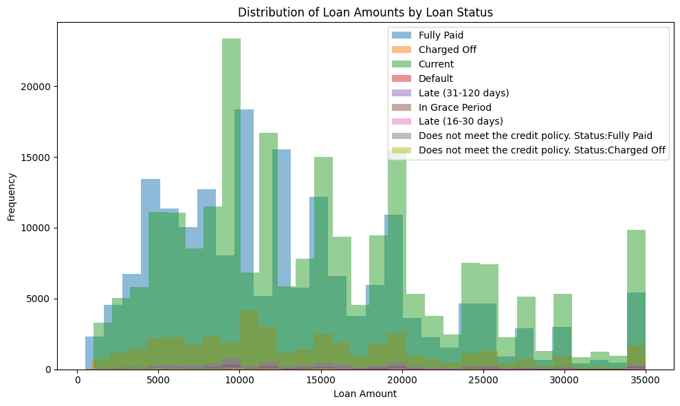

```python
# Visualize the distribution of loan amounts based on loan status
plt.figure(figsize=(10, 6))
loan_status_values = df['loan_status'].unique()
for status in loan_status_values:
    plt.hist(df[df['loan_status'] == status]['loan_amnt'], bins=30, alpha=0.5, label=status)
plt.title('Distribution of Loan Amounts by Loan Status')
plt.xlabel('Loan Amount')
plt.ylabel('Frequency')
plt.legend()
plt.tight_layout()
plt.show()
```

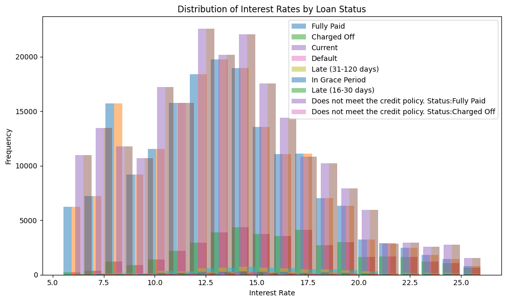

```python
# Visualize the distribution of interest rates based on loan status
plt.figure(figsize=(10, 6))
for status in loan_status_values:
    plt.hist(df[df['loan_status'] == status]['int_rate'], bins=20, alpha=0.5, label=status)
plt.title('Distribution of Interest Rates by Loan Status')
plt.xlabel('Interest Rate')
plt.ylabel('Frequency')
plt.legend()
plt.tight_layout()
plt.show()
```

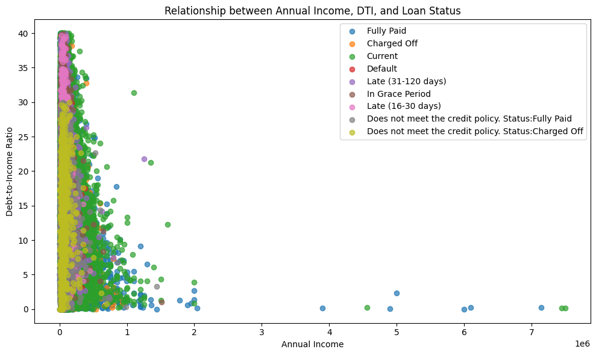

```python
# Explore the relationship between annual income and debt-to-income ratio
plt.figure(figsize=(10, 6))
for status in loan_status_values:
    plt.scatter(df[df['loan_status'] == status]['annual_inc'],
                df[df['loan_status'] == status]['dti'],
                label=status, alpha=0.7)
plt.title('Relationship between Annual Income, DTI, and Loan Status')
plt.xlabel('Annual Income')
plt.ylabel('Debt-to-Income Ratio')
plt.legend()
plt.tight_layout()
plt.show()
```

### Feature engineering

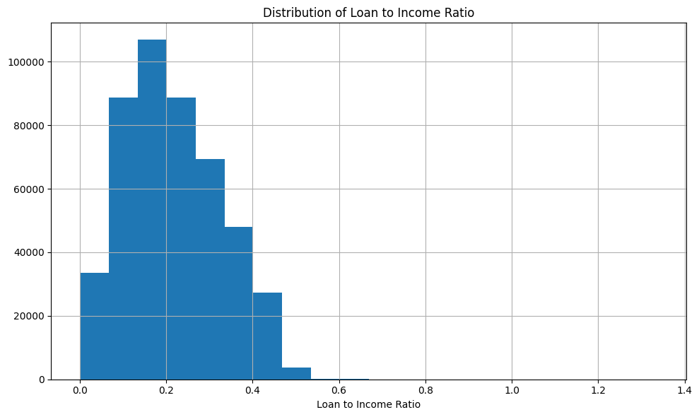

```python
# Feature engineering

# Loan amount to income ratio
loan_data['loan_inc_ratio'] = loan_data['loan_amnt'] / loan_data['annual_inc']

# Distribution plot
plt.figure(figsize=(10, 6))
loan_data['loan_inc_ratio'].hist(bins=20)
plt.xlabel('Loan to Income Ratio')
plt.title('Distribution of Loan to Income Ratio')
plt.tight_layout()
plt.show()
```

```python
# Extract year and month from date columns
loan_data['issue_year'] = loan_data['issue_d'].dt.year
loan_data['issue_month'] = loan_data['issue_d'].dt.month
loan_data['next_pymnt_year'] = loan_data['next_pymnt_d'].dt.year
loan_data['next_pymnt_month'] = loan_data['next_pymnt_d'].dt.month
loan_data['last_pymnt_year'] = loan_data['last_pymnt_d'].dt.year
loan_data['last_pymnt_month'] = loan_data['last_pymnt_d'].dt.month
loan_data['last_credit_pull_year'] = loan_data['last_credit_pull_d'].dt.year
loan_data['last_credit_pull_month'] = loan_data['last_credit_pull_d'].dt.month

# Extracting loan term from 'term' column
loan_data['loan_term'] = loan_data['term'].apply(lambda x: int(x.split()[0]))

# Calculate the average interest rate
avg_interest_rate = loan_data['int_rate'].mean()

# Create a new feature for interest rate difference
loan_data['int_rate_diff'] = loan_data['int_rate'] - avg_interest_rate

# Calculate debt-to-income ratio
loan_data['dti_ratio'] = loan_data['dti'] / loan_data['annual_inc']

# Calculate credit utilization ratio
loan_data['credit_util_ratio'] = loan_data['revol_bal'] / loan_data['total_rev_hi_lim']

# Create a binary indicator for loan status (1 for 'Charged Off', 0 for others)
loan_data['loan_status_binary'] = (loan_data['loan_status'] == 'Charged Off').astype(int)
```

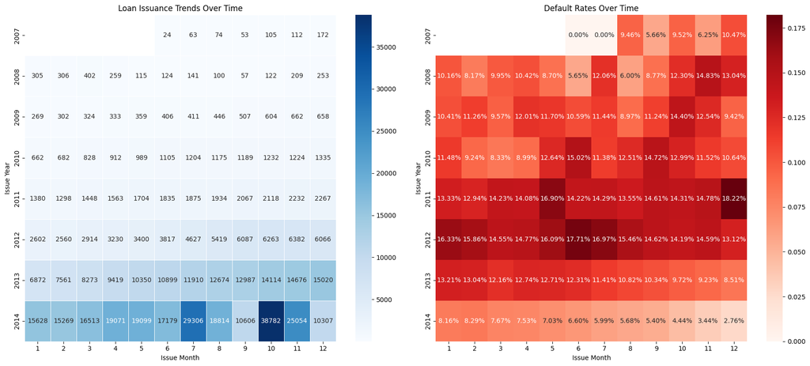

```python
# Analyze loan issuance trends over time

# Group data by issue year and month
issue_date_counts = loan_data.groupby(['issue_year', 'issue_month']).size().unstack()

# Calculate default rates by issue year and month
default_rates_by_date = loan_data.groupby(['issue_year', 'issue_month'])['loan_status_binary'].mean().unstack()

# Plot loan issuance trends and default rates side by side horizontally
fig, axes = plt.subplots(1, 2, figsize=(18, 8))

# Plot loan issuance trends
sns.heatmap(issue_date_counts, cmap='Blues', annot=True, fmt='g', linewidths=.5, ax=axes[0])
axes[0].set_title('Loan Issuance Trends Over Time')
axes[0].set_xlabel('Issue Month')
axes[0].set_ylabel('Issue Year')

# Plot default rates over time
sns.heatmap(default_rates_by_date, cmap='Reds', annot=True, fmt='.2%', ax=axes[1])
axes[1].set_title('Default Rates Over Time')
axes[1].set_xlabel('Issue Month')
axes[1].set_ylabel('Issue Year')

plt.tight_layout()
plt.show()
```

The most noticeable insight is that in 2014, there was a significant increase in loan issuances, particularly in October, where over 38,000 loans were issued. This suggests a surge in lending activity during that specific month and year. possibly indicating a strategic move by the lending institution to boost lending during that period. Interestingly, the heatmap shows that the default rates were highest in the years 2011 and 2012, suggesting that loans issued during these periods were more likely to default. The variation in default rates across different years highlights potential patterns or trends that may influence credit risk and loan performance.

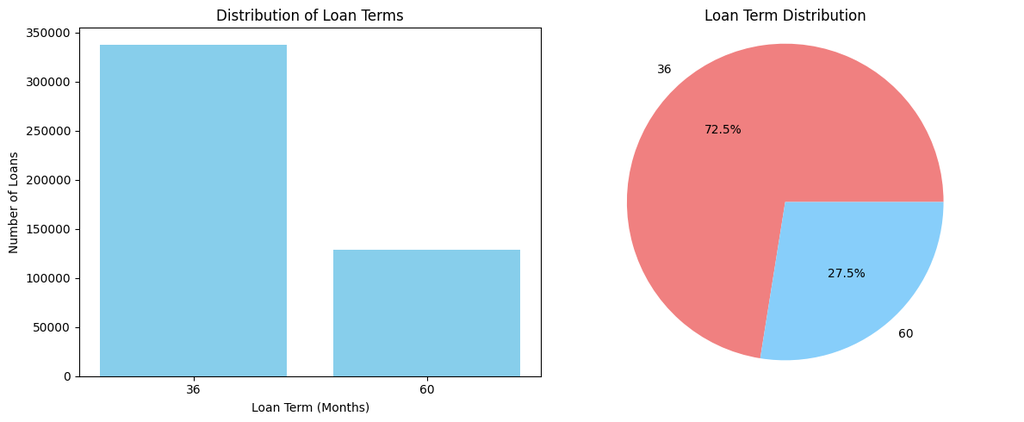

```python
# Get the distribution of loan terms
term_counts = loan_data['loan_term'].value_counts()

# Plot the distribution of loan terms
plt.figure(figsize=(12, 5))

# Plot loan terms
plt.subplot(1, 2, 1)
plt.bar(term_counts.index.astype(str), term_counts, color='skyblue')
plt.title('Distribution of Loan Terms')
plt.xlabel('Loan Term (Months)')
plt.ylabel('Number of Loans')

# Plot a pie chart for loan terms
plt.subplot(1, 2, 2)
plt.pie(term_counts, labels=term_counts.index.astype(str), autopct='%1.1f%%', colors=['lightcoral', 'lightskyblue'])
plt.title('Loan Term Distribution')
plt.axis('equal')

plt.tight_layout()
plt.show()
```

> The bar chart and pie chart collectively reveal that the majority of loans in the dataset have a 36-month term, constituting a substantial portion of the loan portfolio. Conversely, the 60-month term, while still popular, represents a smaller proportion of the total loans.

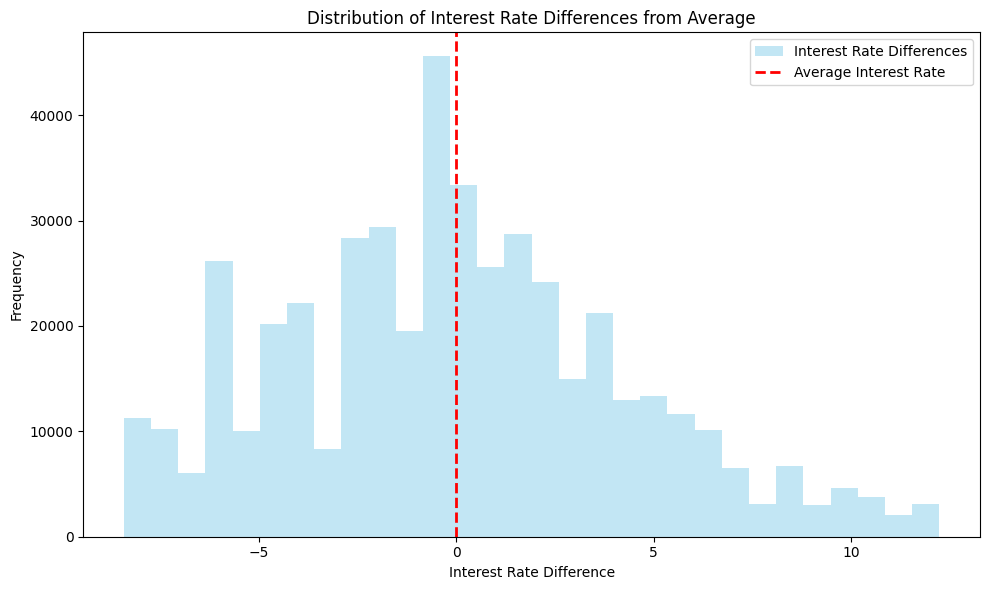

```python
# Compare individual loan interest rates to the average interest rate

# Plot the distribution of individual loan interest rate differences
plt.figure(figsize=(10, 6))
plt.hist(loan_data['int_rate_diff'], bins=30, alpha=0.5, color='skyblue', label='Interest Rate Differences')
plt.axvline(0, color='red', linestyle='dashed', linewidth=2, label='Average Interest Rate')
plt.title('Distribution of Interest Rate Differences from Average')
plt.xlabel('Interest Rate Difference')
plt.ylabel('Frequency')
plt.legend()
plt.tight_layout()
plt.show()
```

### Correlation analysis

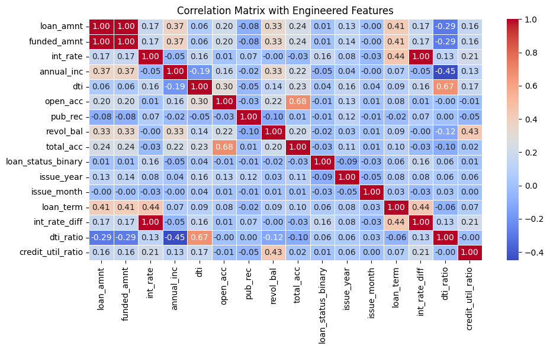

```python
# Select relevant columns for correlation analysis
selected_columns_with_engineered = ['loan_amnt', 'funded_amnt', 'int_rate', 'annual_inc',
                                    'dti', 'open_acc', 'pub_rec', 'revol_bal', 'total_acc',
                                    'loan_status_binary', 'issue_year', 'issue_month',
                                    'loan_term', 'int_rate_diff', 'dti_ratio', 'credit_util_ratio']

# Calculate and visualize correlation matrix
correlation_matrix_with_engineered = loan_data[selected_columns_with_engineered].corr()
plt.figure(figsize=(10, 6))
sns.heatmap(correlation_matrix_with_engineered, annot=True, cmap='coolwarm', fmt=".2f", linewidths=.5)
plt.title('Correlation Matrix with Engineered Features')
plt.savefig('/kaggle/working/correlation.png')
plt.tight_layout()
plt.show()
```

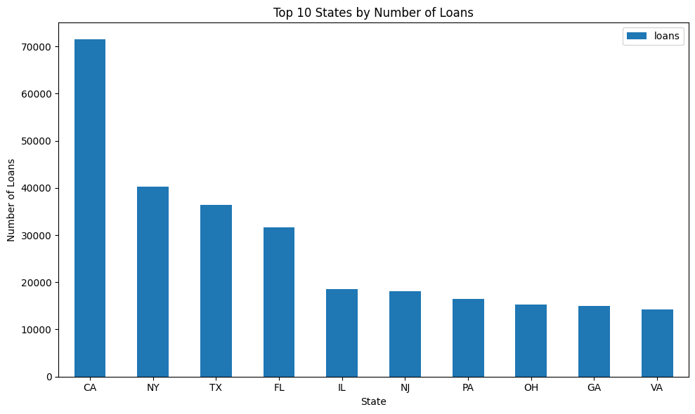

```python
# Group by 'addr_state' and count the number of loans
loan_states = loan_data.groupby('addr_state')['id'].count().reset_index(name='loans')

# Plot the bar chart
fig, ax = plt.subplots(figsize=(10, 6))
top_10 = loan_states.nlargest(10, 'loans')
top_10.plot.bar(x='addr_state', y='loans', rot=0, ax=ax)
plt.title("Top 10 States by Number of Loans")
plt.xlabel("State")
plt.ylabel("Number of Loans")
plt.tight_layout()
plt.show()
```

```python
# Plot the choropleth map
fig = px.choropleth(loan_states,
                    locations='addr_state',
                    locationmode='USA-states',
                    color='loans',
                    scope='usa',
                    title='Number of Loans by State',
                    color_continuous_scale='blues')
fig.update_geos(fitbounds="locations", visible=False)
fig.show()
```

[interactive chart not shown]

> The map reveals that California (CA) has the highest number of loans, with over 70,000 loans. New York (NY) follows with around 40,000 loans, and Texas (TX) is close behind with approximately 36,000 loans.

### Suggestions for business improvement

- Focus on 36-Month Terms:

  > The majority of loans in the dataset have a 36-month term. Consider continuing to offer and promote these shorter-term loans, as they are more popular among borrowers.
- Strategic Issuance in High-Performing Months:

  > Analyze the factors contributing to the surge in loan issuances in specific months, such as the notable increase in October 2014. Consider replicating successful strategies during those high-performing months.
- Manage Default Rates:

  > Address the higher default rates observed in 2011 and 2012. Evaluate the underwriting criteria during those periods and identify any patterns or risk factors contributing to increased default rates. Implement strategies to mitigate default risks.
- Diversify Marketing Strategies:

  > Explore and diversify marketing strategies to attract a broader customer base. Understand the preferences and characteristics of borrowers with successful repayment histories and target similar demographics.
- Optimize Interest Rates:

  > Analyze the distribution of interest rates and their impact on loan performance. Consider optimizing interest rates to remain competitive while ensuring profitability and managing default risks.
- Enhance Geographic Presence:

  > Assess the geographic distribution of loans and identify regions with high demand. Consider expanding or refining the company's presence in those areas to tap into potential markets.
- Customer Education and Transparency:

  > Enhance customer education regarding loan terms, interest rates, and repayment processes. Transparency in communication can build trust and improve customer satisfaction.
- Adapt to Economic Conditions:

  > Stay vigilant to economic conditions that may impact borrower repayment capabilities. Develop adaptive strategies to navigate economic fluctuations and minimize the impact on loan performance.
- Continuous Monitoring and Adaptation:

  > Establish a robust monitoring system to track key performance indicators over time. Regularly revisit and adapt business strategies based on evolving market conditions and customer behaviors.
- Optimize Current Loan Portfolio:

  > Since a significant portion of loans is labeled as "Current," focus on optimizing the management and servicing of these loans. Implement strategies to minimize the risk of loans transitioning into delinquency.
- Customer Engagement for Fully Paid Loans:

  > For loans labeled as "Fully Paid," leverage this positive outcome to engage with customers. Consider soliciting feedback, offering loyalty incentives for repeat business, and encouraging satisfied customers to refer others.
- Mitigate Risk for Delinquent Loans:

  > Given the lower frequencies in other loan statuses, pay special attention to loans with delinquent statuses. Implement proactive measures such as targeted communication, flexible repayment plans, or refinancing options to mitigate the risk of default.
- Enhance Communication Strategies:

  > Improve communication strategies for borrowers across different loan statuses. Provide clear and transparent communication regarding payment schedules, outstanding balances, and any available support or resources in case of financial difficulties.
- Customized Marketing for Different Loan Statuses:

  > Tailor marketing efforts based on the loan status. For instance, develop campaigns to encourage borrowers with fully paid loans to consider additional financial products or services. For borrowers with delinquent status, provide resources to help them get back on track.
- Implement Predictive Analytics:

  > Utilize predictive analytics to forecast the likelihood of loans transitioning into different statuses. This can aid in early intervention strategies for loans showing signs of potential issues.
- Customer Retention Programs:

  > Design customer retention programs for borrowers with fully paid loans to foster long-term relationships. Offer exclusive benefits, promotions, or loyalty programs to incentivize them to choose the company for future financial needs.
- Diversify Loan Products:

  > Explore diversification of loan products to attract a wider range of customers. Different loan products may appeal to various segments of the market, potentially reducing the concentration of loans in the "Current" status.